# Assignment 1 - Language Development in ASD - Power and simulations

Studygroup 4

25-09-2020

```r
#loading packages
pacman::p_load(tidyverse, lme4, simr)

#Setting R's random generator to obtain the same results each time
set.seed(123)
```

## Welcome to the third exciting part of the Language Development in ASD exercise

In this part of the assignment, we try to figure out how a new study should be planned (i.e. how many participants?) in order to have enough power to replicate the findings (ensuring our sample size is adequate, our alpha at 0.05 and our beta at 0.8): 1- if we trust the estimates of the current study. Report the power analysis and comment on what you can (or cannot) use its estimates for. 2- if we are skeptical of the current study. Report the power analysis and comment on what you can (or cannot) use its estimates for. 3- if we only have access to 30 participants. Identify the power for each relevant effect and discuss whether it’s worth to run the study and why The list above is also what you should discuss in your code-less report.

## Learning objectives

- Learn how to calculate statistical power
- Critically appraise how to apply frequentist statistical power

### Exercise 1

How much power does your study have (if your model estimates are quite right)? - Load your dataset (both training and testing), fit your favorite model, assess power for your effects of interest (probably your interactions).

```r
#loading data merged data from Sarahs code
df <- read_csv("Merged_df.csv")
df <- subset(df, select = c(Child.ID, Visit, Diagnosis, CHI_MLU, verbalIQ1))

#Removing Na's
df <- df[!is.na(df$CHI_MLU), 1:5]

df <- df %>% mutate(Diagnosis = as.factor(Diagnosis))
                    #Child.ID = as.factor(Child.ID)

#Favorite model, we chose to remove the interaction between socialization and diagnosis, since it does not add very much to the model and to keep it simple
m1 <- lme4::lmer(CHI_MLU ~ I(Visit^2) + Visit*Diagnosis + verbalIQ1+(1|Child.ID), df, REML = FALSE)
summary(m1)
```

```
## Linear mixed model fit by maximum likelihood  ['lmerMod']
## Formula: CHI_MLU ~ I(Visit^2) + Visit * Diagnosis + verbalIQ1 + (1 | Child.ID)
##    Data: df
##
##      AIC      BIC   logLik deviance df.resid
##    559.5    591.1   -271.7    543.5      379
##
## Scaled residuals:
##      Min       1Q   Median       3Q      Max
## -2.80449 -0.56796 -0.03802  0.54900  2.94860
##
## Random effects:
##  Groups   Name        Variance Std.Dev.
##  Child.ID (Intercept) 0.1264   0.3555
##  Residual             0.1802   0.4245
## Number of obs: 387, groups:  Child.ID, 67
##
## Fixed effects:
##                    Estimate Std. Error t value
## (Intercept)       -0.491558   0.185676  -2.647
## I(Visit^2)        -0.046068   0.008670  -5.313
## Visit              0.421297   0.063295   6.656
## DiagnosisTD       -0.408346   0.132243  -3.088
## verbalIQ1          0.079132   0.007896  10.022
## Visit:DiagnosisTD  0.249336   0.025402   9.815
##
## Correlation of Fixed Effects:
##             (Intr) I(V^2) Visit  DgnsTD vrbIQ1
## I(Visit^2)   0.430
## Visit       -0.508 -0.957
## DiagnosisTD -0.263 -0.006  0.145
## verbalIQ1   -0.744  0.003 -0.005 -0.141
## Vst:DgnssTD  0.250  0.019 -0.226 -0.664  0.006
```

```r
#Power estimation
  #For interaction
powerVD1 = powerSim(m1,fixed("Visit:Diagnosis"), nsim = 200)
```

```
## Simulating: |                                                                  |Simulating: |=                                                                 |Simulating: |==                                                                |Simulating: |===                                         …
```

```r
  #For verbal IQ
powerI1 = powerSim(m1, fixed("verbalIQ1"), nsim=200)
```

```
## Simulating: |                                                                  |Simulating: |=                                                                 |Simulating: |==                                                                |Simulating: |===                                         …
```

- Report the power analysis and comment on what you can (or cannot) use its estimates for.

```r
#Estimated power
  #For interaction
powerVD1
```

```
## Power for predictor 'Visit:Diagnosis', (95% confidence interval):
##       100.0% (98.17, 100.0)
##
## Test: Kenward Roger (package pbkrtest)
##
## Based on 200 simulations, (0 warnings, 0 errors)
## alpha = 0.05, nrow = 387
##
## Time elapsed: 0 h 0 m 28 s
##
## nb: result might be an observed power calculation
```

```r
  #For Verbal IQ
powerI1
```

```
## Power for predictor 'verbalIQ1', (95% confidence interval):
##       100.0% (98.17, 100.0)
##
## Test: Kenward Roger (package pbkrtest)
##       Effect size for verbalIQ1 is 0.079
##
## Based on 200 simulations, (0 warnings, 0 errors)
## alpha = 0.05, nrow = 387
##
## Time elapsed: 0 h 0 m 28 s
##
## nb: result might be an observed power calculation
```

- Test how many participants you would have to have to replicate the findings (assuming the findings are correct)

```r
#How many participants?
  #For interaction
powerCurveVD1 = powerCurve(m1,fixed("Visit:Diagnosis"), along="Child.ID", nsim=50)
```

```
## Simulating: |                                                                  |Simulating: |=                                                                 |Simulating: |==                                                                |Simulating: |===                                         …
```

```r
  #For verbal IQ
powerCurveI1 = powerCurve(m1,fixed("verbalIQ1"), along="Child.ID", nsim=200)
```

```
## Simulating: |                                                                  |Simulating: |=                                                                 |Simulating: |==                                                                |Simulating: |===                                         …
```

```r
  #Plots
print(powerCurveVD1)
```

```
## Power for predictor 'Visit:Diagnosis', (95% confidence interval),
## by largest value of Child.ID:
##       4: 34.00% (21.21, 48.77) - 17 rows
##      11: 92.00% (80.77, 97.78) - 56 rows
##      19: 100.0% (92.89, 100.0) - 97 rows
##      27: 100.0% (92.89, 100.0) - 139 rows
##      34: 100.0% (92.89, 100.0) - 180 rows
##      42: 100.0% (92.89, 100.0) - 227 rows
##      50: 100.0% (92.89, 100.0) - 266 rows
##      58: 100.0% (92.89, 100.0) - 307 rows
##      65: 100.0% (92.89, 100.0) - 346 rows
##      72: 100.0% (92.89, 100.0) - 387 rows
##
## Time elapsed: 0 h 0 m 46 s
```

```r
print(powerCurveI1)
```

```
## Power for predictor 'verbalIQ1', (95% confidence interval),
## by largest value of Child.ID:
##       4: 10.00% ( 6.22, 15.02) - 17 rows
##      11: 88.00% (82.67, 92.16) - 56 rows
##      19: 99.50% (97.25, 99.99) - 97 rows
##      27: 100.0% (98.17, 100.0) - 139 rows
##      34: 100.0% (98.17, 100.0) - 180 rows
##      42: 100.0% (98.17, 100.0) - 227 rows
##      50: 100.0% (98.17, 100.0) - 266 rows
##      58: 100.0% (98.17, 100.0) - 307 rows
##      65: 100.0% (98.17, 100.0) - 346 rows
##      72: 100.0% (98.17, 100.0) - 387 rows
##
## Time elapsed: 0 h 3 m 7 s
```

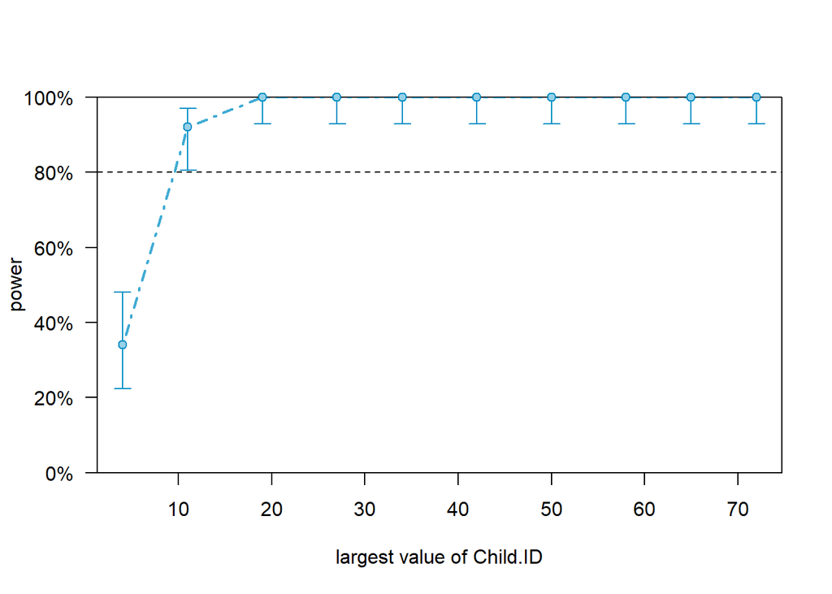

```r
plot(powerCurveVD1)
```

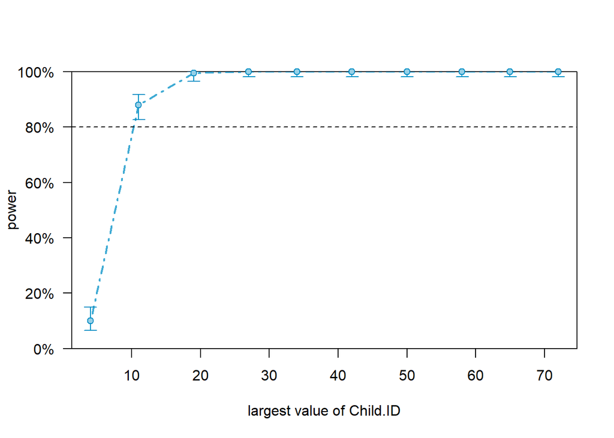

```r
plot(powerCurveI1)
```

### Exercise 2

How would you perform a more conservative power analysis? - Identify and justify a minimum effect size for each of your relevant effects - take the model from exercise 1 and replace the effects with the minimum effect size that you’d accept.

```r
#Making a new model to run the replaced effects with the minimum effect size
m2 <- m1

#Setting the fixed effects
  #For interaction
fixef(m2)["Visit:DiagnosisTD"] <- 0.1
  #For verbal IQ
fixef(m2)["verbalIQ1"] <- 0.03
```

- assess the power curve by Child.ID, identifying an ideal number of participants to estimate each effect

```r
#Assesing power
powerCurveVD2 = powerCurve(m2, fixed("Visit:Diagnosis"), along = "Child.ID", nsim = 200)
```

```
## Simulating: |                                                                  |Simulating: |=                                                                 |Simulating: |==                                                                |Simulating: |===                                         …
```

```r
powerCurveI2 = powerCurve(m2, fixed("verbalIQ1"), along = "Child.ID", nsim = 200)
```

```
## Simulating: |                                                                  |Simulating: |=                                                                 |Simulating: |==                                                                |Simulating: |===                                         …
```

```r
print(powerCurveVD2)
```

```
## Power for predictor 'Visit:Diagnosis', (95% confidence interval),
## by largest value of Child.ID:
##       4: 11.00% ( 7.02, 16.18) - 17 rows
##      11: 31.00% (24.67, 37.91) - 56 rows
##      19: 43.50% (36.52, 50.67) - 97 rows
##      27: 65.50% (58.47, 72.06) - 139 rows
##      34: 81.00% (74.87, 86.19) - 180 rows
##      42: 88.00% (82.67, 92.16) - 227 rows
##      50: 90.50% (85.56, 94.18) - 266 rows
##      58: 93.00% (88.53, 96.12) - 307 rows
##      65: 96.00% (92.27, 98.26) - 346 rows
##      72: 97.00% (93.58, 98.89) - 387 rows
##
## Time elapsed: 0 h 3 m 8 s
```

```r
print(powerCurveI2)
```

```
## Power for predictor 'verbalIQ1', (95% confidence interval),
## by largest value of Child.ID:
##       4:  6.00% ( 3.14, 10.25) - 17 rows
##      11: 18.00% (12.94, 24.04) - 56 rows
##      19: 34.50% (27.94, 41.53) - 97 rows
##      27: 66.00% (58.98, 72.53) - 139 rows
##      34: 77.00% (70.54, 82.64) - 180 rows
##      42: 86.00% (80.41, 90.49) - 227 rows
##      50: 88.00% (82.67, 92.16) - 266 rows
##      58: 93.50% (89.14, 96.49) - 307 rows
##      65: 97.50% (94.26, 99.18) - 346 rows
##      72: 98.50% (95.68, 99.69) - 387 rows
##
## Time elapsed: 0 h 3 m 6 s
```

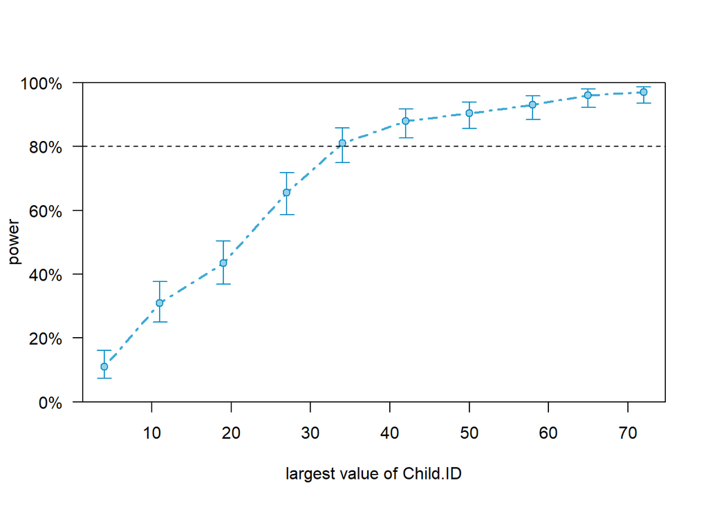

```r
#Plotting curves
plot(powerCurveVD2)
```

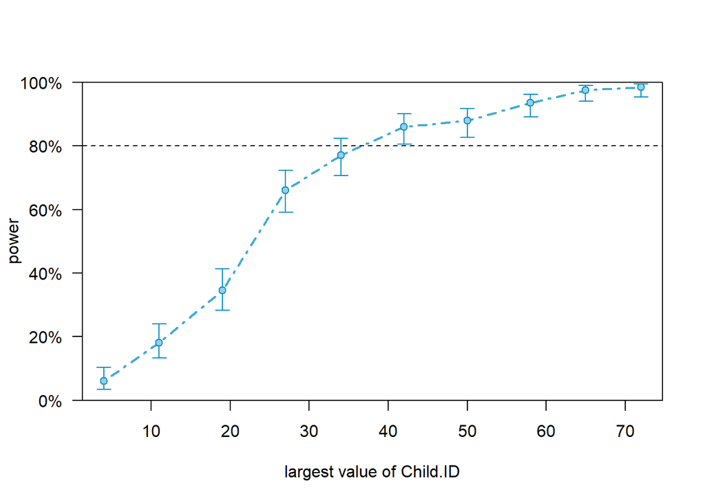

```r
plot(powerCurveI2)
```

- if your power estimates do not reach an acceptable threshold simulate additional participants and repeat the previous analysis

### Exercise 3

Assume you only have the resources to collect 30 kids (15 with ASD and 15 TDs). Identify the power for each relevant effect and discuss whether it’s worth to run the study and why

```r
#Making new model
m3 <- m1

#Extending participants
  #extended by child.id, means that we cannot get 15 participant of each, but no other way makes it work
m3 <- extend(m3, along = "Child.ID", n=30)
  #Checking the data
m3_data <- getData(m3)


#Assesing power with no change in the fixed effects
  #Interaction
powerVD3 = powerSim(m3,fixed("Visit:Diagnosis"),nsim=200)
```

```
## Simulating: |                                                                  |Simulating: |=                                                                 |Simulating: |==                                                                |Simulating: |===                                         …
```

```r
powerVD3
```

```
## Power for predictor 'Visit:Diagnosis', (95% confidence interval):
##       100.0% (98.17, 100.0)
##
## Test: Kenward Roger (package pbkrtest)
##
## Based on 200 simulations, (0 warnings, 0 errors)
## alpha = 0.05, nrow = 174
##
## Time elapsed: 0 h 0 m 21 s
##
## nb: result might be an observed power calculation
```

```r
  #Verbal IQ
powerI3 = powerSim(m3,fixed("verbalIQ1"),nsim = 200)
```

```
## Simulating: |                                                                  |Simulating: |=                                                                 |Simulating: |==                                                                |Simulating: |===                                         …
```

```r
powerI3
```

```
## Power for predictor 'verbalIQ1', (95% confidence interval):
##       100.0% (98.17, 100.0)
##
## Test: Kenward Roger (package pbkrtest)
##       Effect size for verbalIQ1 is 0.079
##
## Based on 200 simulations, (0 warnings, 0 errors)
## alpha = 0.05, nrow = 174
##
## Time elapsed: 0 h 0 m 21 s
##
## nb: result might be an observed power calculation
```

```r
#Power curves
powerCurveVD3 = powerCurve(m3,fixed("Visit:Diagnosis"),along="Child.ID", nsim=200)
```

```
## Simulating: |                                                                  |Simulating: |=                                                                 |Simulating: |==                                                                |Simulating: |===                                         …
```

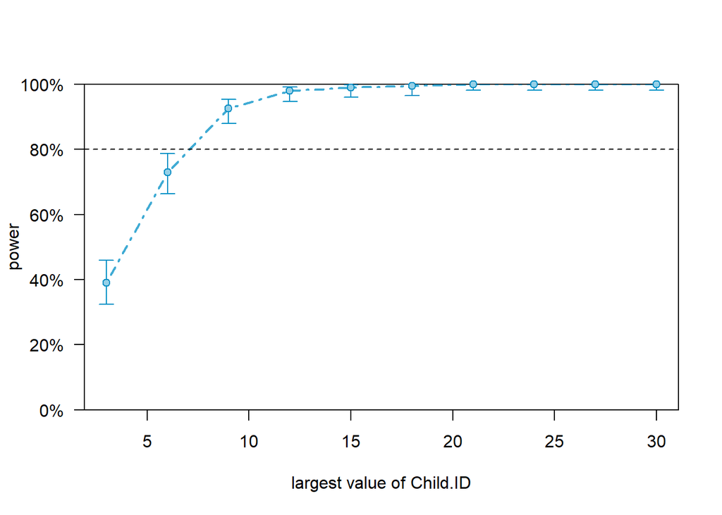

```r
plot(powerCurveVD3)
```

```r
powerCurveI3 = powerCurve(m3,fixed("verbalIQ1"),along="Child.ID", nsim=200)
```

```
## Simulating: |                                                                  |Simulating: |=                                                                 |Simulating: |==                                                                |Simulating: |===                                         …
```

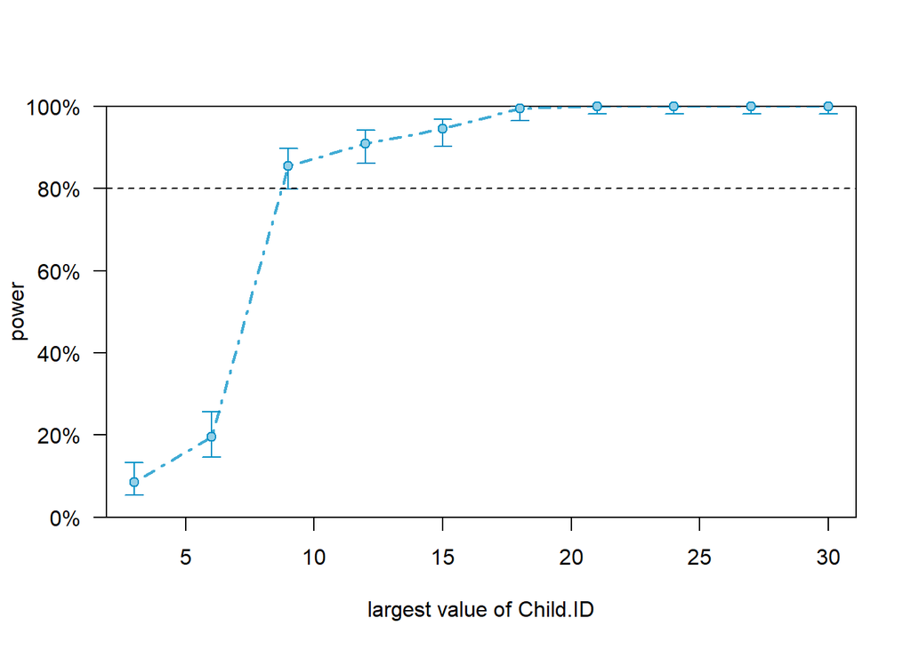

```r
plot(powerCurveI3)
```

```r
#Setting new fixed effect as the ones we did before
m4 <- m3

fixef(m4)["Visit:DiagnosisTD"] <- 0.1
fixef(m4)["verbalIQ1"] <- 0.03

#Powercurves with new fixed effects
powerCurveVD4 = powerCurve(m4,fixed("Visit:Diagnosis"),along="Child.ID", nsim=200)
```

```
## Simulating: |                                                                  |Simulating: |=                                                                 |Simulating: |==                                                                |Simulating: |===                                         …
```

```r
powerCurveVD4
```

```
## Power for predictor 'Visit:Diagnosis', (95% confidence interval),
## by largest value of Child.ID:
##       3:  9.00% ( 5.42, 13.85) - 17 rows
##       6: 19.00% (13.81, 25.13) - 35 rows
##       9: 34.00% (27.47, 41.02) - 50 rows
##      12: 40.00% (33.15, 47.15) - 68 rows
##      15: 43.00% (36.04, 50.17) - 86 rows
##      18: 49.50% (42.37, 56.64) - 103 rows
##      21: 60.50% (53.36, 67.32) - 121 rows
##      24: 63.00% (55.91, 69.70) - 139 rows
##      27: 70.00% (63.14, 76.26) - 156 rows
##      30: 74.50% (67.87, 80.39) - 174 rows
##
## Time elapsed: 0 h 2 m 48 s
```

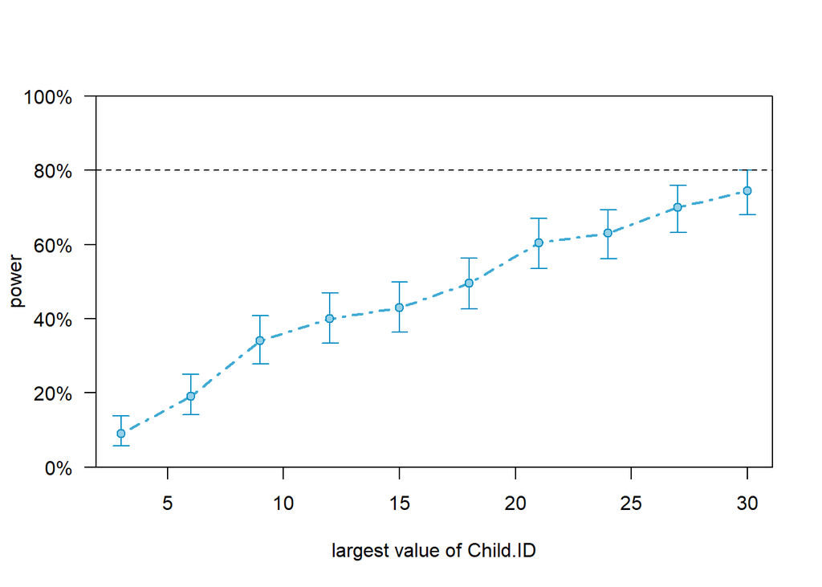

```r
plot(powerCurveVD4)
```

```r
powerCurveI4 = powerCurve(m4,fixed("verbalIQ1"),along="Child.ID", nsim=200)
```

```
## Simulating: |                                                                  |Simulating: |=                                                                 |Simulating: |==                                                                |Simulating: |===                                         …
```

```r
powerCurveVD4
```

```
## Power for predictor 'Visit:Diagnosis', (95% confidence interval),
## by largest value of Child.ID:
##       3:  9.00% ( 5.42, 13.85) - 17 rows
##       6: 19.00% (13.81, 25.13) - 35 rows
##       9: 34.00% (27.47, 41.02) - 50 rows
##      12: 40.00% (33.15, 47.15) - 68 rows
##      15: 43.00% (36.04, 50.17) - 86 rows
##      18: 49.50% (42.37, 56.64) - 103 rows
##      21: 60.50% (53.36, 67.32) - 121 rows
##      24: 63.00% (55.91, 69.70) - 139 rows
##      27: 70.00% (63.14, 76.26) - 156 rows
##      30: 74.50% (67.87, 80.39) - 174 rows
##
## Time elapsed: 0 h 2 m 48 s
```

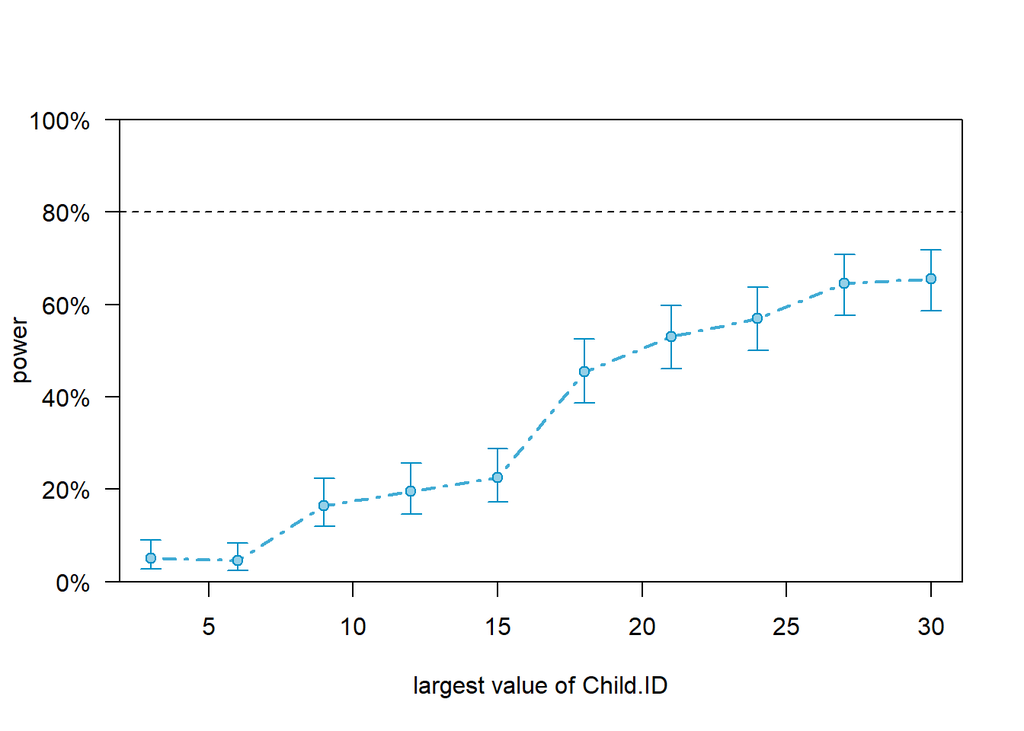

```r
plot(powerCurveI4)
```